# Extensions and Applications

As you know, this semester we have focused almost entirely on building predictive models with textual data. If you doubt how much we’ve covered and learned, I strongly recommend going back to the first few classes and seeing how simple the concepts introduced in those notes (hopefully) seem to you now.

I have mentioned many times, however, that most of the techniques I have been introducing are not specific to textual data and can in fact be applied in a wide range of different supervised and unsupervised settings. Today, I am going to show you how this can be done. I won’t hide anything away in helper functions and will only call other popular and public R packages. To get started, let’s load in all of these packages and set a few options to make the output easier to read in RMarkdown:

```r
library(tidyverse)
library(glmnet)
library(xgboost)
library(irlba)
library(stringi)
library(FNN)
theme_set(theme_minimal())
options(dplyr.summarise.inform = FALSE)
options(readr.show_col_types = FALSE)
options(width = 76L)
```

## Predicted NBA Shots

### The Data

The first dataset we will consider consists of observations of shots from the NBA (I made this a while ago and lost the original documentation, but I think it is from the 16-17 season). The variable that we want to predict is called `fgm`; it is equal to 0 when the shot was missed and 1 when the shot was made.

```r
nba <- read_csv("../data/nba_shots.csv")
nba
```

```
## # A tibble: 20,000 × 11
##      fgm period shot_clock dribbles touch_time shot_dist pts_type
##    <dbl>  <dbl>      <dbl>    <dbl>      <dbl>     <dbl>    <dbl>
##  1     0      2       18.6        0        0.8      23.7        2
##  2     0      4       11          0        1.2      26.7        3
##  3     0      3        4.9        2        1.8       9.4        2
##  4     0      4        2          3        3.1      24.3        2
##  5     0      4        9.9        4        3.9      14.6        2
##  6     1      3       12.7        6        6.7       9.1        2
##  7     0      1        3.1        4        5.9       3.5        2
##  8     0      2       24          2        4.2      35.2        3
##  9     0      3       19.8        0        0.7      22.7        3
## 10     0      4       11.6        2        3.2       3.9        2
## # … with 19,990 more rows, and 4 more variables: close_def_dist <dbl>,
## #   shooter_height <dbl>, defender_height <dbl>, player_name <chr>
```

Before we start building predicting models, notice that there is no `train_id` variable in this dataset. Usually, the task of splitting the data into a training and validation (and testing, holdout, tuning, or whatever other data partitions you make) are the job of the analyst working with the data. Let’s see how to add a train id to the data. In the code below, I have used some additional code to make sure the distribution of 0s and 1s is exactly the same in the training and validation sets:

```r
set.seed(1)

nba <- nba %>%
  group_by(fgm) %>%
  mutate(rnum = runif(n())) %>%
  mutate(train_id = if_else(rnum < quantile(rnum, 0.6), "train", "valid")) %>%
  select(-rnum) %>%
  ungroup()
```

The `set.seed` on the first line of the code makes sure that the split into training and validation data will be the same everytime we run the code.

### Using Logistic Regression

The first real model we discussed this semester was logistic regression. We never actually ran unpenalised logistic regression in R, though we did talk about it in the first few classes. The unpenalised version if useful when you have a small number of variables or need to produce p-values, so let’s see how it works in R.

Logistic regression can be run in R using the `glm` function, which is included in the basic installation of R. We specify a *formula* object that describes the variable we are trying to predict (`fgm`) and the variables we are using to predict it. We will also filter the data to only train on the training data and select the family option as `binomial()` to run logistic regression.

```r
model <- glm(
  fgm ~ shot_dist + shooter_height + defender_height + factor(period),
  data = filter(nba, train_id == "train"),
  family = binomial()
)
```

I used the `factor` function above to tell the regression model to treat the period of the game as a categorical, rather than continuous variable. Note that the `glm` function assumes that the response variable is coded as 0s and 1s. In the next case study we will see how to create this encoding when it is not already done in the original data.

Let’s look at the output of the model:

```r
model
```

```
##
## Call:  glm(formula = fgm ~ shot_dist + shooter_height + defender_height +
##     factor(period), family = binomial(), data = filter(nba, train_id ==
##     "train"))
##
## Coefficients:
##     (Intercept)        shot_dist   shooter_height  defender_height
##       1.6520855       -0.0466861        0.0019912       -0.0145911
## factor(period)2  factor(period)3  factor(period)4  factor(period)5
##      -0.0218715        0.0025508       -0.0663625        0.0002786
## factor(period)6  factor(period)7
##       0.0749014       11.5716020
##
## Degrees of Freedom: 11999 Total (i.e. Null);  11990 Residual
## Null Deviance:       16640
## Residual Deviance: 16140     AIC: 16160
```

Hopefully you can remember what the coefficients represent and how we could use them to build a predictive model. To have R automatically created predicted probabilities, we will use the `predict` function. Notice that we want to predict on the entire dataset, not just the training data.

```r
pred <- predict(model, newdata = nba, type = "response")
head(pred)
```

```
##         1         2         3         4         5         6
## 0.3768793 0.3472858 0.5517618 0.3790118 0.4924303 0.5681209
```

How well does this model perform? We don’t have a fancy wrapper function to compute an error rate. Instead, here is some base-R code that computes the error rate on the training and validation sets:

```r
tapply(nba$fgm != (pred > 0.5), nba$train_id, mean)
```

```
##   train   valid
## 0.42275 0.42100
```

The dataset has been selected to have a 50/50 split of baskets made and baskets missed. Our model is not amazingly predictive, but it is noticably better than randomly guessing.

### Using Penalised Regression

Now, let’s see how we could use the penalised logistic regression model on this dataset. This is a bit more involved because we first have to create numerical matricies from our dataset because the penalised regression function will not work directly with a data frame object. This is very common and true for most machine learning algorithms in R (and Python for that matter).

We will use a few functions that you probably have never seen to create a matrix and vector version of the dataset. We will use all of the variables in the data for training the model.

```r
mf <- model.frame(fgm ~ . -1,
                  data = select(nba, -train_id))
mt <- attr(mf, "terms")
y <- model.response(mf)
X <- model.matrix(mt, mf)

X_train <- X[nba$train_id == "train",]
y_train <- y[nba$train_id == "train"]
```

Now, we can use the `cv.glmnet` with the proper family setting to run penalised logistic regression on the data.

```r
model <- cv.glmnet(X_train, y_train, family = "binomial")
```

To get the cross-validation curve, we can use the `plot` function.

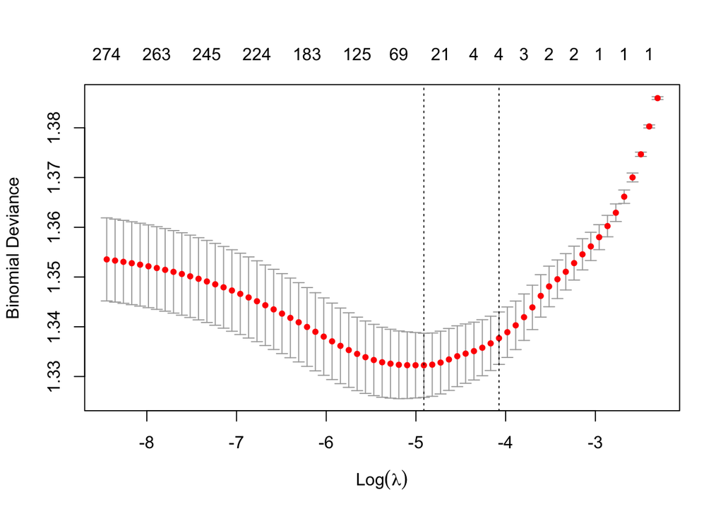

```r
plot(model)
```

To look at the coefficients, we can use the coef function. There are a lot of variable because of the player names, so we will look at just the head of the coefficients.

```r
head(coef(model), 20)
```

```
## 20 x 1 sparse Matrix of class "dgCMatrix"
##                                     s1
## (Intercept)                 0.27207798
## period                      .
## shot_clock                  0.01235174
## dribbles                    .
## touch_time                 -0.00253012
## shot_dist                  -0.04221547
## pts_type                    .
## close_def_dist              0.03700200
## shooter_height              .
## defender_height             .
## player_nameaaron brooks     .
## player_nameaaron gordon     .
## player_nameal horford       .
## player_nameal jefferson     .
## player_nameAl-Farouq Aminu  .
## player_namealan anderson    .
## player_namealex len         .
## player_namealexis ajinca    .
## player_nameAllen Crabbe     .
## player_namealonzo gee       .
```

A slightly modified syntax for the `predict` function produces the predicted probabilities:

```r
pred <- predict(model, newx = X, type = "response")
```

And the same code from before works to find the error rate:

```r
tapply(nba$fgm != (pred > 0.5), nba$train_id, mean)
```

```
##     train     valid
## 0.4171667 0.4130000
```

The penalised version with all of the variables works slightly better, but the difference is very minor.

### Using Gradient Boosted Trees

Let’s also see how gradient boosted trees work in R without the wrapper functions. First, we create a matrix version of the data.

```r
mf <- model.frame(fgm ~ . -1,
                  data = select(nba, -train_id))
mt <- attr(mf, "terms")
y <- model.response(mf)
X <- model.matrix(mt, mf)

X_train <- X[nba$train_id == "train",]
y_train <- y[nba$train_id == "train"]
X_valid <- X[nba$train_id == "valid",]
y_valid <- y[nba$train_id == "valid"]
```

Then, we wrap the training and validation data into specifically optimised objects for training.

```r
data_train <- xgb.DMatrix(data = X_train, label = y_train)
data_valid <- xgb.DMatrix(data = X_valid, label = y_valid)
watchlist <- list(train=data_train, valid=data_valid)
```

Now, we can run the `xgb.train` function from the xgboost package.

```r
model <- xgb.train(
  data = data_train,
  max_depth = 3,
  eta = 0.01,
  nrounds = 200,
  nthread = 2,
  objective = "multi:softmax",
  eval_metric = "merror",
  watchlist = watchlist,
  verbose = TRUE,
  print_every_n = 25,
  num_class = 2L
)
```

Predicting the values from this model again uses the `predict` function and we can test the predictive power in the same way as before.

```r
pred <- predict(model, newdata = X)
tapply(nba$fgm != (pred > 0.5), nba$train_id, mean)
```

```
##     train     valid
## 0.3969167 0.4007500
```

Here we see that the model improves more, though again only slightly. Clearly there is some minor benefit to allowing for interactions before terms in the model.

### Principal Component Analysis

As a final method, let’s see PCA applied to the dataset. We will work with the `X` matrix produced in the previous section. Then, we call the function `prcomp_irlba` on the (transpose) of the dataset and convert the results into a data frame.

```r
rot <- as_tibble(prcomp_irlba(t(X), n = 2, scale. = TRUE, center = TRUE)$rotation)
rot$fgm <- nba$fgm
```

Now, let’s plot the data:

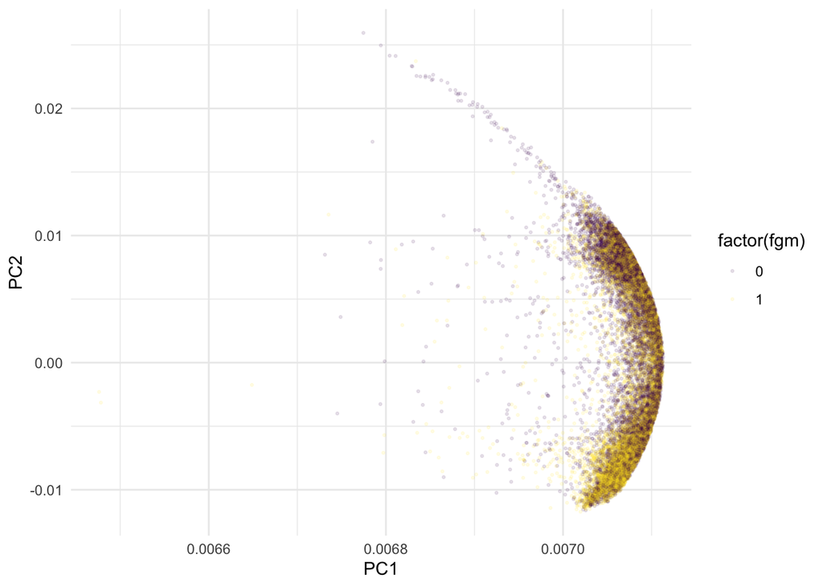

```r
rot %>%
  ggplot(aes(PC1, PC2)) +
    geom_point(aes(color = factor(fgm)), alpha = 0.1, size = 0.5) +
    scale_color_viridis_d()
```

You will notice that there are some regions in which field goals are more or less likely to be made, but it much harder to make much of this plot than it was with the textual data (why?). Note that the strange curve results from several of the variables having certain types of dependencies on one another.

## Predicting Crime Types

### The Data

As a second dataset, we will look a dataset I created of reported crimes that occured in Chicago.

```r
chi <- read_csv("../data/chi_crimes_5.csv")
chi
```

```
## # A tibble: 50,000 × 8
##    crime_type       year month   day  hour location       latitude longitude
##    <chr>           <dbl> <dbl> <dbl> <dbl> <chr>             <dbl>     <dbl>
##  1 narcotics        2001    11    17    18 STREET             41.9     -87.6
##  2 robbery          2002     3     8     2 OTHER              42.0     -87.7
##  3 prostitution     2007     2    10    17 STREET             41.9     -87.7
##  4 narcotics        2005     8     6    11 ALLEY              41.7     -87.6
##  5 theft            2003     7     9    15 SMALL RETAIL …     41.9     -87.6
##  6 criminal_damage  2012     3    27    22 RESIDENCE          41.7     -87.6
##  7 theft            2003     9    19    12 HOSPITAL BUIL…     41.8     -87.6
##  8 robbery          2006    12    18    21 ALLEY              41.7     -87.7
##  9 theft            2003     1    16    21 OTHER              41.8     -87.6
## 10 criminal_damage  2012    10    19    19 RESIDENCE-GAR…     41.9     -87.7
## # … with 49,990 more rows
```

Our goal will be to use the details of the crime to determin what type of crime had been committed. Before we get started, let’s add a training identifier into the data.

```r
set.seed(1)

chi <- chi %>%
  group_by(crime_type) %>%
  mutate(rnum = runif(n())) %>%
  mutate(train_id = if_else(rnum < quantile(rnum, 0.6), "train", "valid")) %>%
  select(-rnum) %>%
  ungroup()
```

The code here is essentially the same as the code for the binary case in the first example.

### Using Penalised Regression

It is possible to run unpenalised multinomial regression, but it is not nearly as common nor is it usually very insightful. So let’s jump straight to penalised regression. The code to create a data matrix in the multivariate prediction case is the exact the same as previous example with the variable names changed.

```r
chi$location <- stri_sub(chi$location, 1L, 17L)

mf <- model.frame( ~ . -1,
                  data = select(chi, -train_id, -crime_type))
mt <- attr(mf, "terms")
y <- chi$crime_type
X <- model.matrix(mt, mf)

X_train <- X[chi$train_id == "train",]
y_train <- y[chi$train_id == "train"]
```

We can run the same `cv.glmnet` function from before, but need to set the family equal to “multinomial”. While not required, I will set a few other options to make the model run a bit faster (these are options that I set within the wrapper function we have been calling all semester).

```r
model <- cv.glmnet(X_train, y_train, family = "multinomial",
                   nfolds = 3L, alpha = 0.8, lambda.min.ratio = 0.05)
```

We can again use the `coef` function to get the function coefficients, but the results from the multinomial model are put together in a rather complex format. I will use a few functions to make the results match what we have seen through the rest of the semester.

```r
temp <- coef(model)
beta <- Reduce(cbind, temp)
colnames(beta) <- names(temp)
beta <- beta[apply(beta != 0, 1, any),,drop=FALSE]
beta
```

```
## 49 x 5 sparse Matrix of class "dgCMatrix"
##                           criminal_damage     narcotics  prostitution
## (Intercept)                  -33.28760982 -1.015824e+02 -1.143001e+02
## year                           .          -7.289887e-03 -4.946089e-02
## month                          .          -1.924756e-03 -9.989106e-03
## hour                           .           3.615454e-02  .
## locationABANDONED BUILDIN      .           6.511974e-01  .
## locationAIRPORT TERMINAL       .           .             .
## locationAIRPORT/AIRCRAFT       .           .             .
## locationALLEY                 -0.50483833  4.474840e-01  .
## locationAPARTMENT              1.20695649  .             .
## locationATHLETIC CLUB          .           .             .
## locationBANK                   .           .             .
## locationBAR OR TAVERN          .           .             .
## locationCHA APARTMENT          .           .             .
## locationCHA HALLWAY/STAIR      .           1.476648e+00  .
## locationCHA PARKING LOT/G      .           2.481717e+00  .
## locationCHURCH/SYNAGOGUE/      0.48115627  .             .
## locationCOMMERCIAL / BUSI      0.01648895 -5.478581e-02  .
## locationCONSTRUCTION SITE      .           .             .
## locationCONVENIENCE STORE      .           .             .
## locationCTA BUS                .           .             .
## locationCTA BUS STOP           .           .             .
## locationCTA PLATFORM           .           .             .
## locationCTA TRAIN              .           .             .
## locationCURRENCY EXCHANGE      .           .             .
## locationDEPARTMENT STORE       .           .             .
## locationDRIVEWAY - RESIDE      0.51462555  .             .
## locationDRUG STORE             .           .             .
## locationFACTORY/MANUFACTU      0.39260886  .             .
## locationGAS STATION            .           .             .
## locationGROCERY FOOD STOR      .          -1.752034e-01  .
## locationHOSPITAL BUILDING      .           .             .
## locationHOTEL/MOTEL            .           .             3.225329e+00
## locationMEDICAL/DENTAL OF      .           .             .
## locationPARK PROPERTY         -0.06550656  .             .
## locationPARKING LOT/GARAG      0.06643727  .             .
## locationPOLICE FACILITY/V      .           1.725117e+00  .
## locationRESIDENCE              1.17446437  .             .
## locationRESIDENCE PORCH/H      .           .             .
```

[output cut: 46 more lines]

```
## locationPARKING LOT/GARAG   .            .
## locationPOLICE FACILITY/V   .            .
## locationRESIDENCE          -0.581314930  0.176391398
## locationRESIDENCE PORCH/H   0.190874853 -0.019784697
## locationRESIDENCE-GARAGE    .            .
## locationRESTAURANT          0.034122990  .
## locationSCHOOL, PUBLIC, B  -0.214989565  .
## locationSIDEWALK            .           -2.271966540
## locationSMALL RETAIL STOR   0.451430205  0.586855836
## locationSTREET              .           -0.577493833
## locationVACANT LOT/LAND     .            .
## locationVEHICLE NON-COMME  -0.118772640  .
## locationVEHICLE-COMMERCIA   .            0.427526355
## latitude                   -0.985758712  2.055774661
## longitude                   1.668514875  2.527139044
```

We use the type argument to the predict function to produce predictions based on the labels in the original data.

```r
pred <- predict(model, newx = X, type = "class")
head(pred)
```

```
##      1
## [1,] "prostitution"
## [2,] "theft"
## [3,] "prostitution"
## [4,] "robbery"
## [5,] "theft"
## [6,] "criminal_damage"
```

This makes finding the error rate of the model fairly easy:

```r
tapply(chi$crime_type != pred, chi$train_id, mean)
```

```
##     train     valid
## 0.5543333 0.5564500
```

Given that there are five classes here, this is not a terrible error rate. Let’s see how to make a confusion matrix:

```r
table(chi$crime_type, pred, chi$train_id)
```

```
## , ,  = train
##
##                  pred
##                   criminal_damage narcotics prostitution robbery theft
##   criminal_damage            2082       144         2215     209  1350
##   narcotics                   335      1686         2202     986   791
##   prostitution                 70       311         5145     355   119
##   robbery                     251       975         1843    1739  1192
##   theft                      1031       173         1752     326  2718
##
## , ,  = valid
##
##                  pred
##                   criminal_damage narcotics prostitution robbery theft
##   criminal_damage            1418       105         1411     143   923
##   narcotics                   217      1130         1425     690   538
##   prostitution                 46       191         3438     244    81
##   robbery                     191       665         1277    1100   767
##   theft                       680       123         1179     233  1785
```

Which crimes seem hardest or easiest to differentiate?

### Using Gradient Boosted Trees

Running gradient boosted trees requires a bit more work and involves something that several R packages for machine learning require: we need to recode the labels as integers. Here is the code to do this, which involves creating an object `yset` that stores the mapping betwen the codes and the labels in the original data.

```r
mf <- model.frame( ~ . -1,
                  data = select(chi, -train_id, -crime_type))
mt <- attr(mf, "terms")

yset <- unique(chi$crime_type)
y <- match(chi$crime_type, yset) - 1L
X <- model.matrix(mt, mf)

X_train <- X[chi$train_id == "train",]
y_train <- y[chi$train_id == "train"]
X_valid <- X[chi$train_id == "valid",]
y_valid <- y[chi$train_id == "valid"]
```

Now, we can use the same code from before to create the objects needed by xgboost:

```r
data_train <- xgb.DMatrix(data = X_train, label = y_train)
data_valid <- xgb.DMatrix(data = X_valid, label = y_valid)
watchlist <- list(train=data_train, valid=data_valid)
```

And finally, use `xgb.train` to run the model. Notice that we need to change the objective and evaluation metrics to match the multinomial task.

```r
model <- xgb.train(
  data = data_train,
  max_depth = 3,
  eta = 0.01,
  nrounds = 200,
  nthread = 2,
  objective = "multi:softmax",
  eval_metric = "merror",
  watchlist = watchlist,
  verbose = TRUE,
  print_every_n = 25,
  num_class = 5L
)
```

With the model trained, we will make predictions and transform back into the original categories.

```r
pred <- yset[predict(model, newdata = X) + 1L]
tapply(chi$crime_type != pred, chi$train_id, mean)
```

```
##  train  valid
## 0.5439 0.5470
```

As in the first case study, the gradient boosted trees are able to make slightly better predictions at the expense of having a less-interpretable model.

## Predicting Census Tract Income

### The Data

Our last task is a little bit different from anything we have seen this semester. We are going to try to use the location of a census tract (a small region of the US defined for statistical purposes) to predict the median income of households living within the tract. The dataset includes many variables, but we will select just three before getting started:

```r
inc <- read_csv("../data/tract_median_income.csv")
inc <- select(inc, median_income, lon, lat)
inc
```

```
## # A tibble: 63,993 × 3
##    median_income   lon   lat
##            <dbl> <dbl> <dbl>
##  1         98316 -149.  61.3
##  2         96056 -149.  61.3
##  3         79295 -150.  61.3
##  4         89389 -150.  61.3
##  5        112451 -150.  61.3
##  6        119656 -149.  61.2
##  7         57845 -150.  61.3
##  8         53884 -150.  61.2
##  9         35694 -150.  61.2
## 10         67894 -150.  61.2
## # … with 63,983 more rows
```

What is so different about this dataset? The thing we are trying to predict is a continuous number rather than a category. Our goal will be to make predictions that are close to this number rather than focusing on making predictions that are exactly correct.

We will again need to create a training id for the data:

```r
set.seed(1)

inc <- inc %>%
  mutate(rnum = runif(n())) %>%
  mutate(train_id = if_else(rnum < quantile(rnum, 0.6), "train", "valid")) %>%
  select(-rnum)
```

Here, notice that we do not stratify the training identifiers because there are no concrete groups on which to stratify.

### Using Linear Regression

Since we have a continuous variable to predict, we can use standard linear regression with the `lm` function. The syntax is very similar, just a bit simplier, than with `glm`.

```r
model <- lm(
  median_income ~ lon + lat,
  data = filter(inc, train_id == "train")
)
```

Let’s look at the coefficients. Based on these, where do you generally expect to find the most affluent census tracts in the US?

```r
model
```

```
##
## Call:
## lm(formula = median_income ~ lon + lat, data = filter(inc, train_id ==
##     "train"))
##
## Coefficients:
## (Intercept)          lon          lat
##     30942.8        -59.4        595.8
```

We can get predictions from the model once again with the `predict` function. Here, the predictions are dollar amounts:

```r
pred <- predict(model, newdata = inc)
head(pred)
```

```
##        1        2        3        4        5        6
## 76281.57 76360.25 76366.19 76362.67 76349.78 76257.14
```

Our typical error rate does not make sense here. Instead, we will measure a quantited called the root mean squared error, or RMSE.

```r
sqrt(tapply((inc$median_income - pred)**2, inc$train_id, mean))
```

```
##    train    valid
## 29113.56 28872.26
```

### k-Nearest Neighbors

We can run penalised regression and gradient boosted trees on continuous data. Doing this is as simply as the above example with a simple change in the model family selection. However, for this specific application, let’s instead return to a model that will be better suited to this example: KNN.

To run k-nearest neighbors, we will again need to make a data matrix.

```r
mf <- model.frame(median_income ~ lat + lon -1,
                  data = inc)
mt <- attr(mf, "terms")

y <- model.response(mf)
X <- model.matrix(mt, mf)

X_train <- X[chi$train_id == "train",]
y_train <- y[chi$train_id == "train"]
```

Now, we can run k-nearest neighbors using the function `knn.reg`. For continuous responses, KNN will take the average of the neighbors (rather than the most common label). I will start with three neighbors:

```r
pred <- knn.reg(X_train, X, y_train, k = 3)$pred
```

Now, we can see how well this method works:

```r
sqrt(tapply((inc$median_income - pred)**2, inc$train_id, mean))
```

```
##    train    valid
## 15851.50 15709.68
```

It is much more predictive than the previous model. Does that make sense? Why?

## So, why text?

Looking at the above examples have hopefully explained more concretely how to apply the techniques from this class to other data types. You might wonder then why I thought it made sense to focus on textual data.

1. **Lots of variables** The distinguishing feature of our core set of models (penalized regression) is the need to do regression of multi-class classification when there are a very large number of variables. This is a very common problem in many (most?) domains. For example: genetics, engineering, marketing, accounting, finance, operations research, and supply chain management. Text is a good example to work with in class because the features and results should be familiar to anyone familiar with the English language. Most of the other examples require understanding a lot of domain knowledge that will not be common to everyone in the class.
2. **Feature Construction** In order to do text analysis we need to construct features; they are not given to us directly. Some can be created directly from the data, but most often useful features come from selectively summarising the data from the tokens table. Again, this is very common in industry and research applications, where the most interesting data points are observed at a different frequency or unit of measurement than the response variable. For example, think of computing a credit score based on summary statistics selected from a person’s financial history or determining a patient’s prognosis based on a history of medical records and lab reports. As with the lots of variables point, text is just a useful example of this kind of analysis that does not require specialised domain knowledge.
3. **Text is actually quite common** A surprising amount of data being produced and analyzed in industry and research applications contains at least some free text fields. Think, for example, of trying to detect indicators of fraud when investigating a collection emails, or automatically detecting themes or signalling problems by doing text analysis on call center logs. In the age of large datasets, the amount of free text used in all kinds of applications will likely only grow. Being able to know the specific techniques to work with is just another benefit of focusing on textual data.
4. **False Binary: Supervised/Unsupervised** As we have seen, text datasets lend themselves to both modes of analysis simultaneously; this is another common feature of real-world applications that is often lost in other textbook examples of machine learning applications.
5. **Returning to the data** We have made a lot of use of techniques such as negative examples, maximum probability examples, and KWiC models. These have analogs in other spaces too, but are only useful if returning to the original data is meaningful. It often is, but often requires specialised domain knowledge. Text just requires that we can read.

In addition to the basics of supervised and unsupervised learning, you have also gained valuable experience presenting quantitive and qualitative information and combining different kinds of evidence to tell a story and make and argument. There are valuable skills to have as part of a broad liberal arts oriented education.

Hopefully you enjoyed the class and feel like you learned some useful things!